# Breast cancer gene expression profiling in search for response prediction biomarkers.

Homework for SCMIA course.

Author

Maryam Shojaei

Published

April 11, 2026

# 1 Introduction

In this analysis, we explore a breast cancer gene expression dataset from the Gene Expression Omnibus [GEO:GSE25066](https://www.ncbi.nlm.nih.gov/geo/query/acc.cgi?acc=GSE25066).

The aim is to explore patterns in the data, identify differentially expressed genes, and develop gene expression signatures to predict treatment response. In addition, pathway analysis is performed to better understand the underlying biological processes, while accounting for important clinical variables such as ER status, HER2 status, and tumour grade.

The main questions addressed in this study are:

- Which clinical variables contain a strong gene expression signal?
- Can gene expression data be used to develop classifiers to identify breast cancer patient status?

The dataset comprises 22,283 genes measured across 508 patient samples. Key clinical variables like ER status, HER2 status, tumor grade, and treatment response have 0, 13, 24, and 207 missing values, respectively. Samples with missing treatment response were excluded from analyses, resulting in a final dataset of 301 samples.

## 1.1 Clinical variables in the data set

The dataset includes several clinically relevant variables such as ER status, HER2 status, tumor grade, and treatment response. A selection of these clinical features for a subset of samples is shown in the table below.

Selection of available clinical information.

|  | source | age_years | er_status_ihc | pr_status_ihc | her2_status | er_status_ihc_esr1_for indeterminate | clinical_t_stage | clinical_nodal_status | clinical_ajcc_stage | grade | pathologic_response_pcr_rd | pathologic_response_rcb_class | drfs_1_event_0_censored | drfs_even_time_years | esr1_status | erbb2_status | response_group | response_3group |
| --- | --- | --- | --- | --- | --- | --- | --- | --- | --- | --- | --- | --- | --- | --- | --- | --- | --- | --- |
| GSM615096 | ISPY | 37.8 | P | P | N | P | T2 | N1 | IIB | 2 | RD | RCB-III | 1 | 2.346 | P | N | Non_responder | Non_responder |
| GSM615098 | ISPY | 40.7 | N | N | N | N | T3 | N0 | IIB | 3 | RD | RCB-II | 0 | 5.503 | N | N | Non_responder | Partial_responder |
| GSM615099 | ISPY | 40.8 | N | N | N | N | T2 | N1 | IIB | 4=Indeterminate | pCR | RCB-0/I | 0 | 5.424 | N | N | Responder | Complete_responder |
| GSM615100 | ISPY | 35.5 | P | P | N | P | T3 | N1 | IIIA | 2 | RD | RCB-II | 1 | 1.580 | P | N | Non_responder | Partial_responder |
| GSM615101 | ISPY | 52.2 | N | N | N | N | T4 | N0 | IIIB | 3 | RD | RCB-II | 0 | 5.205 | N | N | Non_responder | Partial_responder |
| GSM615102 | ISPY | 38.2 | N | N | I | N | T2 | N0 | IIA | 4=Indeterminate | RD | RCB-II | 1 | 2.732 | N | N | Non_responder | Partial_responder |
| GSM615104 | ISPY | 46.6 | N | N | N | N | T3 | N3 | IIIC | 4=Indeterminate | RD | RCB-III | 1 | 0.783 | N | N | Non_responder | Non_responder |
| GSM615106 | ISPY | 51.1 | N | N | N | N | T3 | N1 | IIIA | 4=Indeterminate | RD | RCB-II | 0 | 4.156 | N | N | Non_responder | Partial_responder |
| GSM615107 | ISPY | 37.8 | N | N | N | N | T3 | N1 | IIIA | 4=Indeterminate | RD | RCB-0/I | 0 | 4.370 | N | N | Responder | Complete_responder |
| GSM615108 | ISPY | 46.6 | P | P | P | P | T3 | N3 | IIIC | 3 | RD | RCB-III | 0 | 4.597 | P | N | Non_responder | Non_responder |

## 1.2 Distributions of certain defined response categories

To understand the distribution of treatment responses, we examined the pathologic response (RCB class) and derived response groups.

Pathologic response (RCB class) – The distribution of samples across RCB classes is shown in the table below.

Distribution of pathologic response (RCB class)

| RCB class | Count |
| --- | --- |
| RCB-0/I | 86 |
| RCB-II | 136 |
| RCB-III | 79 |

Two response variables were defined:

- **Binary response groups (Responder vs Non-responder):** Samples were grouped into responders (RCB-0/I) and non-responders (RCB-II/III).
- **Three-level response groups:** Samples were classified into complete responders, partial responders, and non-responders.

The distributions of these groups are shown in the following tables.

Distribution of binary response groups (Responder vs Non-responder)

| Response group | Count |
| --- | --- |
| Non_responder | 215 |
| Responder | 86 |

Distribution of 3-level clinical response groups

| 3-class response group | Count |
| --- | --- |
| Complete_responder | 86 |
| Non_responder | 79 |
| Partial_responder | 136 |

# 2 Unsupervised data exploration

Spectral maps are very powerful techniques for obtaining an unsupervised view of how the data are structured. A spectral map of the dataset shows that responders and non-responders are not clearly separated, with substantial overlap between the groups, making them difficult to distinguish (Figure 1). The samples were therefore also examined by colouring according to ER status (Figure 1, right panel). In this representation, ER-positive and ER-negative samples are clearly separated along the second principal component (PC2), which explains 9% of the total variation in the log-ratio-transformed gene expression data. This indicates that ER status is a major driver of variation in the dataset and captures a stronger underlying structure than treatment response.

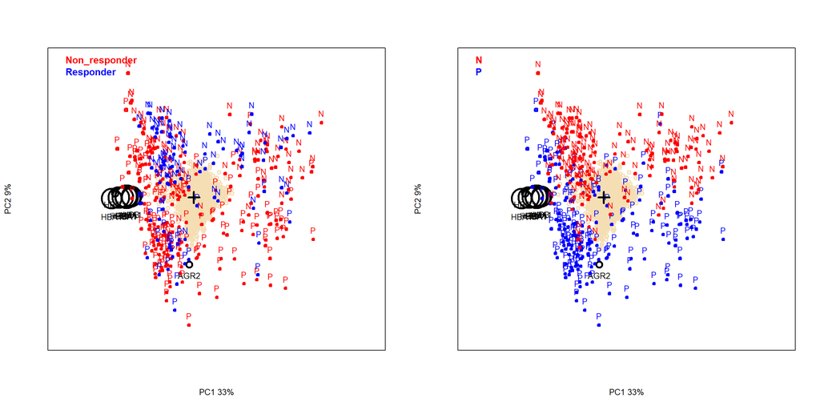

Figure 1: Spectral map of all samples, labelled by ER status and colored by response group (left panel) and ER status (right panel).

The spectral maps of ER-negative (left panel) and ER-positive (right panel) samples, coloured by tumor grade and labelled by HER2 status, provide further insight into subgroup structure (Figure 2). In both panels, HER2-negative (“N”) samples are predominant, indicating limited variability for this variable and suggesting it is unlikely to explain major differences in the data.

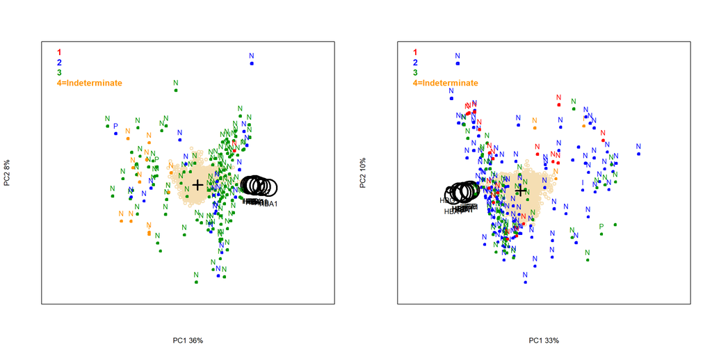

Figure 2: Spectral maps of ER negative (left panel) and ER positive (right panel) samples, colored by grade and labelled by HER2 status.

When colouring all samples by tumor grade, grade 4 tumors appear to separate from the other grades, indicating that grade also contributes to the global structure of the data (Figure 3). However, this effect is less pronounced than that of ER status. HER2 status shows very limited variability across the dataset, with most samples being HER2-negative. This is reflected in the spectral maps for all dataset. When only complete responders and non-responders were considered (excluding partial responders), there was still no clear separation between the two groups (Figure 4). The spectral map continued to show strong overlap, suggesting that treatment response does not clearly structure the data.

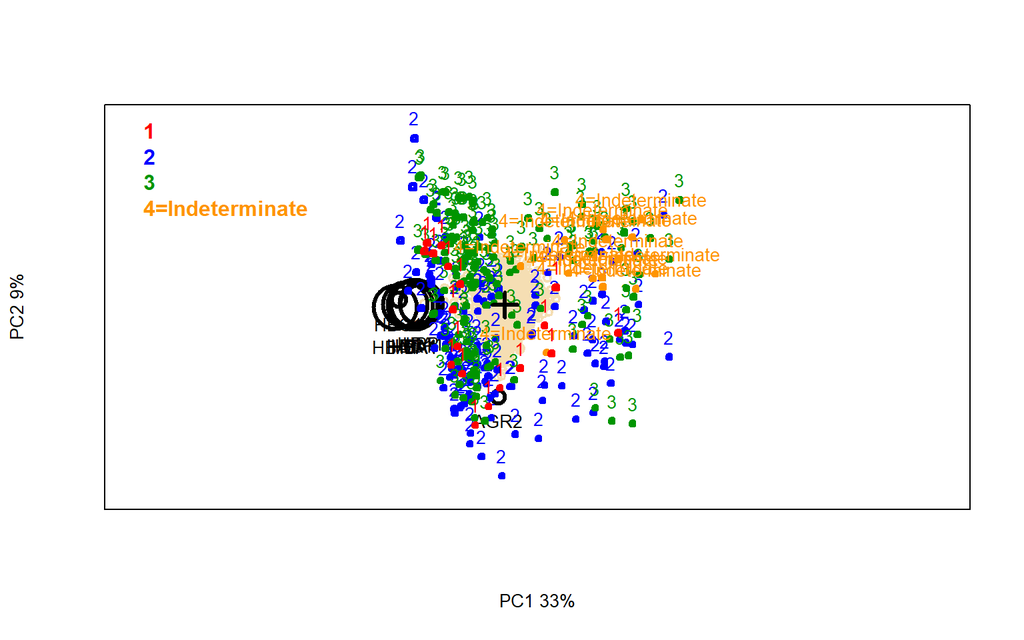

Figure 3: Spectral map of all samples, labelled and colored by grade.

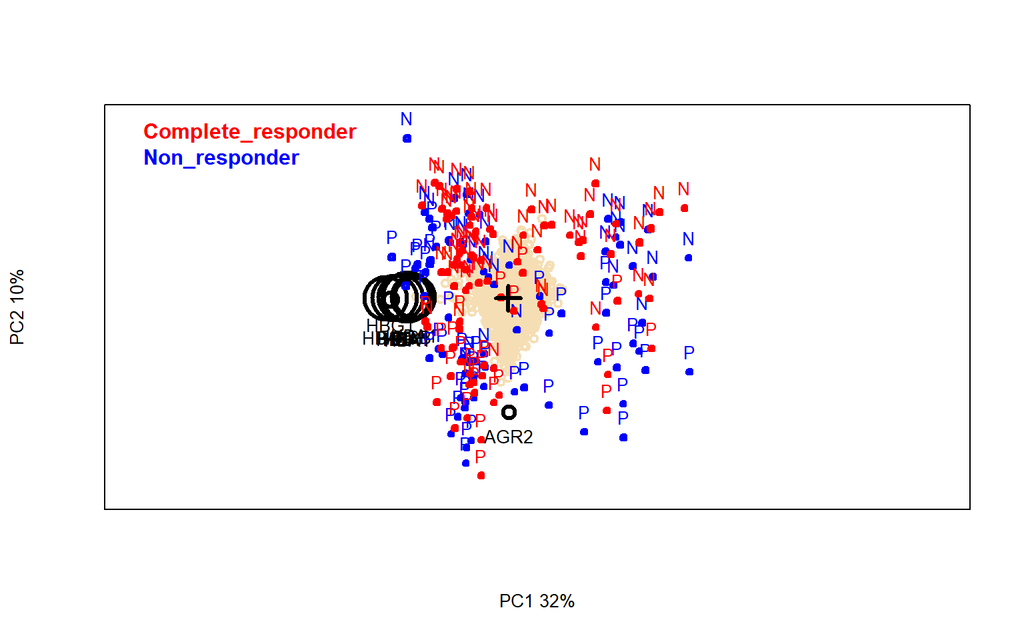

Figure 4: Spectral map of all samples(excluding partial responders), colored by clinical response groups and labelled by ER status.

# 3 Filtering

To reduce the high dimensionality of the dataset and focus on the most informative genes, the gene expression data was filtered based on signal intensity and variance. This combination of signal and variation filtering removes genes with low overall expression or low variability across samples, keeping genes which are most likely to contribute meaningful biological information. To visualize the effect of filtering, a mean versus log-variance plot was generated for all genes, with points coloured according to their filter status.

To visualize the effect of filtering, a mean versus log-variance plot was generated for all genes, with points coloured by filter status. Genes removed by the signal and variation filtering form a dense cloud in the lower-left region of the plot, while the retained, informative genes appear in the upper-right region.

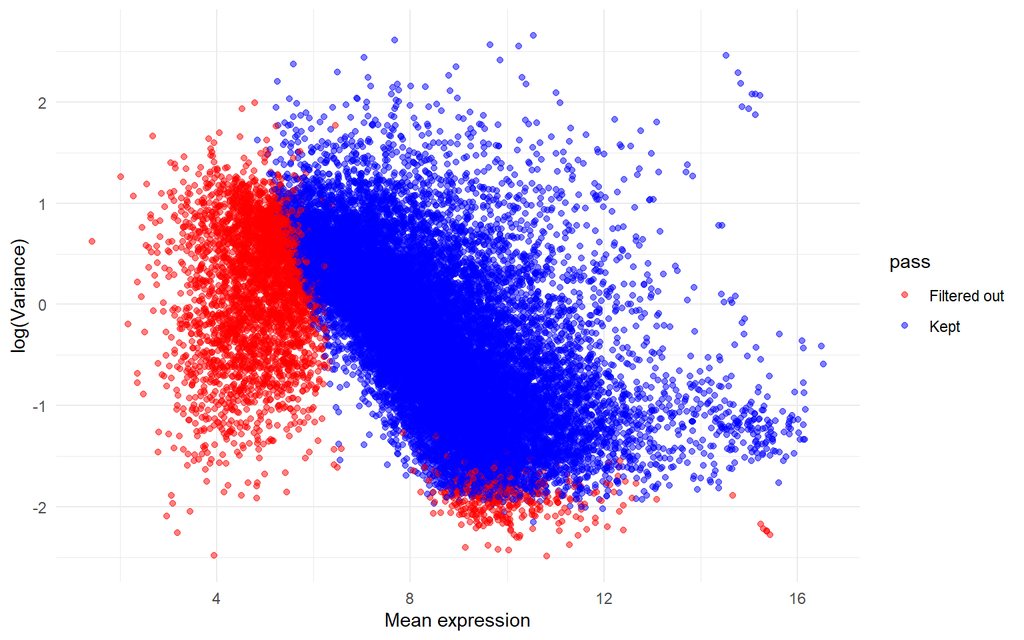

Figure 5: Mean vs Log-Variance of Genes (Threshold: VarCutOff = 0.5).

Increasing the variance threshold to 0.7 resulted in a clearer separation: genes removed by the filtering formed a dense cloud in the lower-left region of the plot (low mean expression and low variance), while the retained genes were more concentrated in the upper-right region, representing higher expression and greater variability. This adjustment improved the selection of genes most likely to carry biologically relevant information.

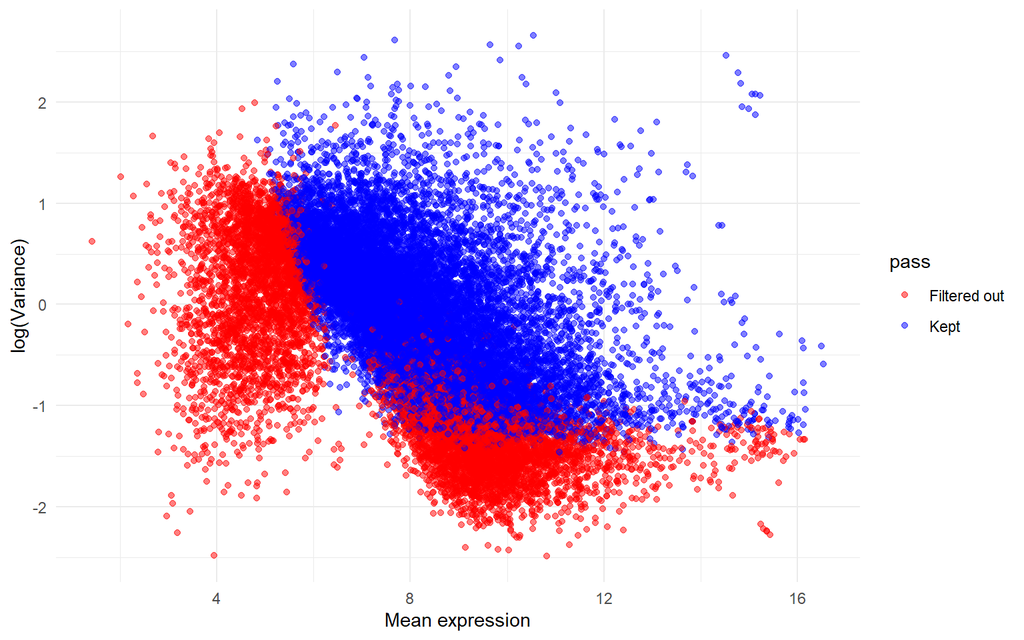

Figure 6: Mean vs Log-Variance of Genes (Threshold: VarCutOff = 0.7).

65.8 % of the genes (14665 of the in total 22283 genes)

# 4 Detecting differential expression

## 4.1 Limma for comparing two groups

Limma was applied to identify differentially expressed genes between several groups: responders versus non-responders, ER-positive versus ER-negative samples, high-grade (grade 4) versus lower-grade tumours, and complete responders versus non-responders. Finally, to account for potential confounding, a model was fitted for treatment response while adjusting for ER status and tumour grade.

These results are illustrated using histograms of p-value distributions. The moderated t-tests indicate that many genes are differentially expressed between responders and non-responders. Based on the raw p-value distribution, approximately 41% of genes appear differentially expressed, while for extreme response (complete responders versus non-responders), this proportion is approximately 29% (Figure 7). For ER status, the proportion is around 61%, while for tumour grade it is about 43% (Figure 8). Importantly, when adjusting for ER status and grade, this proportion decreases to 19% for the responder versus non-responder comparison, indicating that part of the observed signal is explained by these confounding factors (Figure 9).

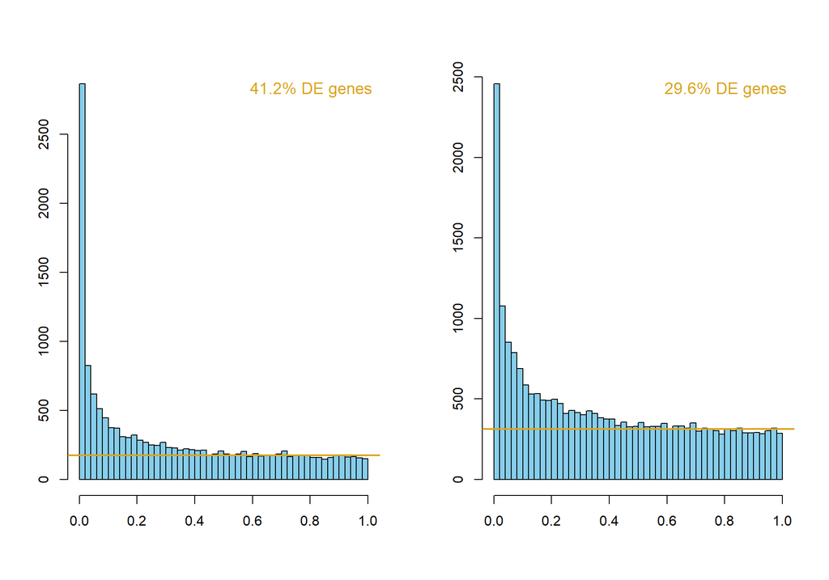

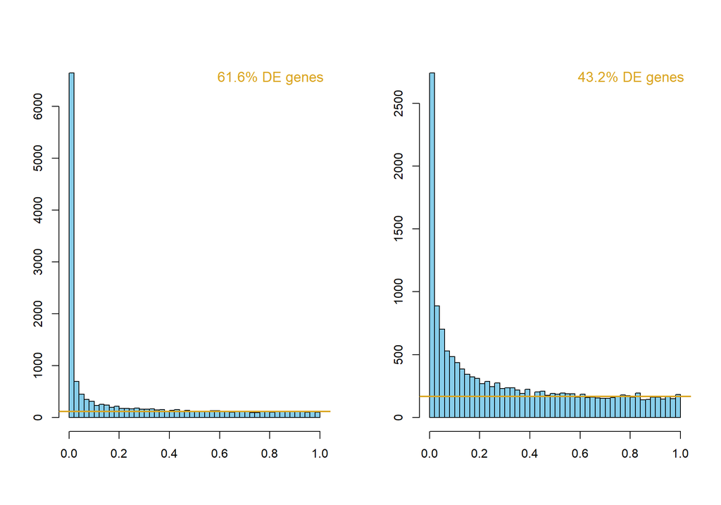

```
Coefficients not estimable: gradepCR gradeRD
```

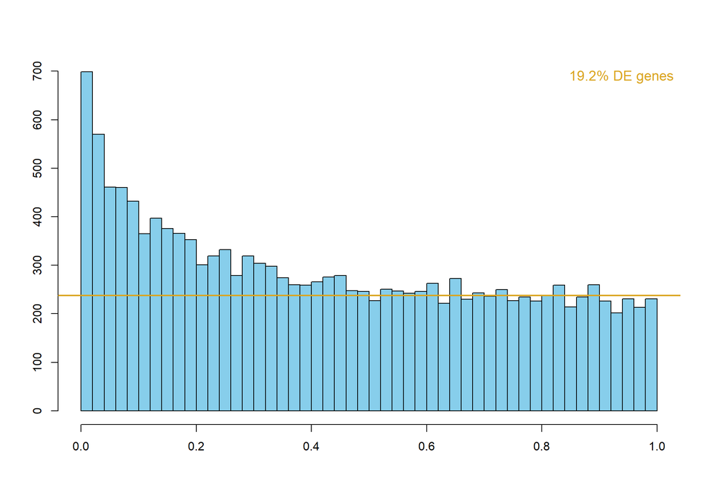

Figure 9: Distribution of p-values when testing for differential expression between responders and non-responders adjusting for ER and grade.

## 4.2 Volcano plots

Volcano plots were used to visualise the results from the Limma analysis by displaying both the magnitude of differential expression (log-fold change) and statistical significance for each comparison.

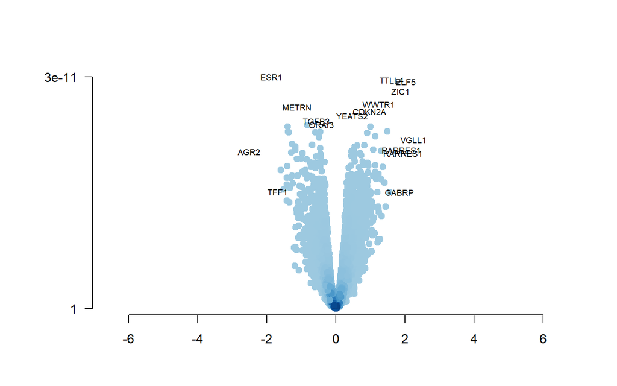

Figure 10: Volvano plot for the test for differential expression between responders and non-responders.

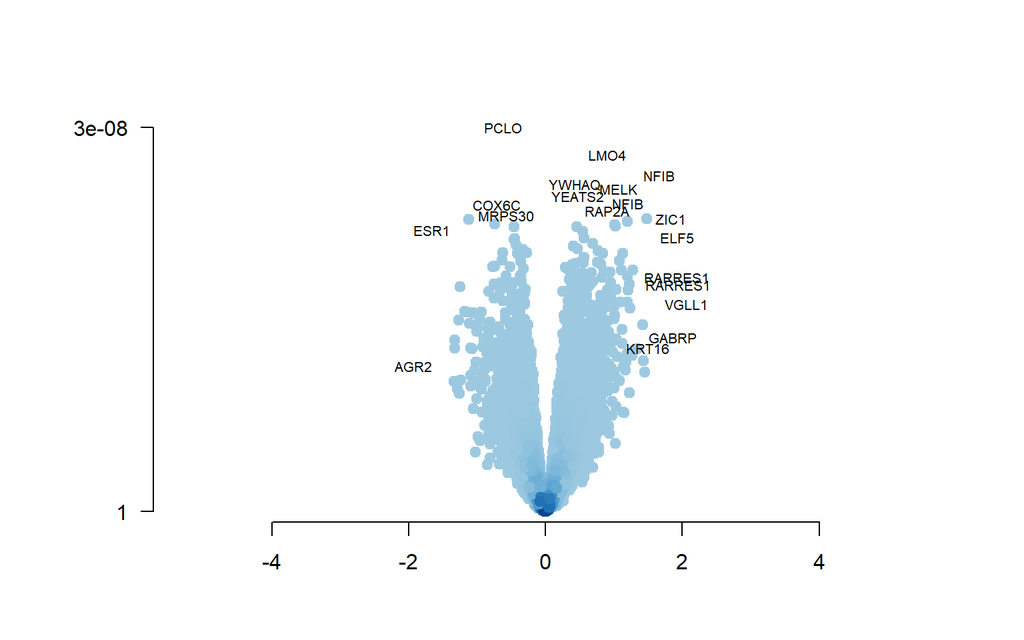

Figure 11: Volvano plot for the test for differential expression between complete responders versus non-responders.

For the ER comparison, p-values are generally much smaller and fold changes are higher, suggesting a stronger and more consistent effect. Some genes are shared across these models, indicating overlapping biological signals (Figure 12).

In contrast, the grade comparison shows a different pattern, with genes such as HBA1, HBG1, and ARPC4 being prominent. The fold changes in this comparison are generally larger than those observed for responder versus non-responder, suggesting a distinct underlying biological effect (Figure 13).

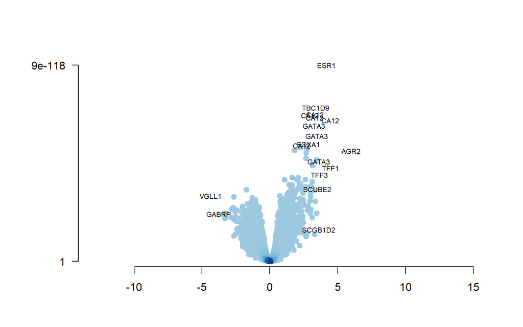

Figure 12: Volvano plot for the test for differential expression between ER-positive and ER-negative.

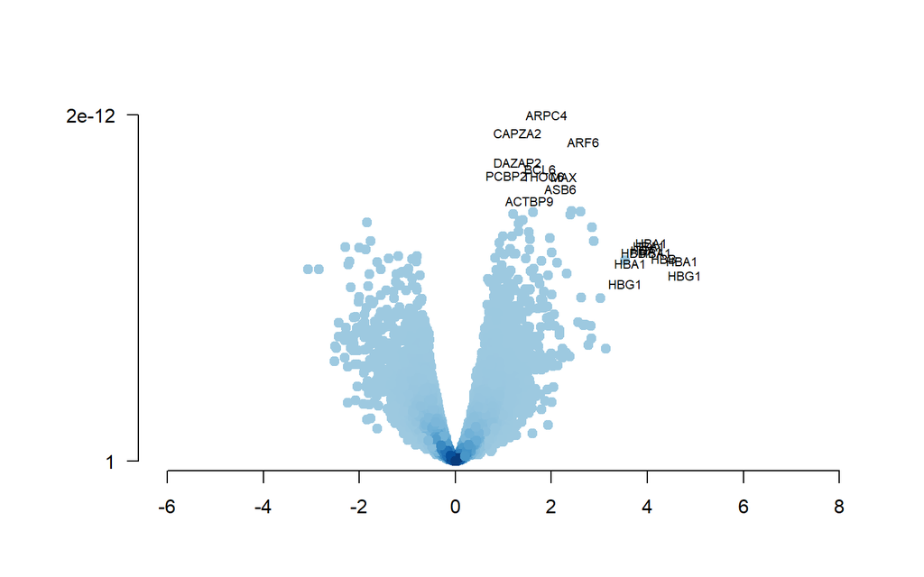

Figure 13: Volvano plot for the test for differential expression between high-grade (grade 4) versus lower-grade tumours.

## 4.3 Table of Top Differentially Expressed Genes

Differentially expressed genes are presented in an annotated table to improve interpretability and support biological validation. For convenience and further exploration, gene symbols are linked to their corresponding Entrez Gene entries, providing direct access to detailed gene information. The tables below show the top 10 most differentially expressed genes for each comparison.

The top genes differ between responder vs non-responder and complete responder vs non-responder comparisons. Notably, ESR1 is the most significant gene in the responder vs non-responder analysis, showing a higher fold change and a lower p-value in the ER-positive vs ER-negative comparison, which may reflect a confounding effect observed in the exploratory analysis.

Table 1: The top 10 most differentially expressed genes between between responders and non-responders.

| SYMBOL | logFC | AveExpr | P.Value | adj.P.Val | Gene.Title |
| --- | --- | --- | --- | --- | --- |
| [ESR1](http://www.ncbi.nlm.nih.gov/gene/2099) | -1.86 | 10.9 | 3.3e-11 | 2.62e-07 | estrogen receptor 1 |
| [TTLL4](http://www.ncbi.nlm.nih.gov/gene/9654) | 1.62 | 7.1 | 4.55e-11 | 2.62e-07 | tubulin tyrosine ligase-like family, member 4 |
| [ELF5](http://www.ncbi.nlm.nih.gov/gene/2001) | 2.03 | 5.59 | 5.37e-11 | 2.62e-07 | E74-like factor 5 (ets domain transcription factor) |
| [ZIC1](http://www.ncbi.nlm.nih.gov/gene/7545) | 1.88 | 5.96 | 1.47e-10 | 5.38e-07 | Zic family member 1 |
| [WWTR1](http://www.ncbi.nlm.nih.gov/gene/25937) | 1.24 | 7.17 | 5.5e-10 | 1.61e-06 | WW domain containing transcription regulator 1 |
| [METRN](http://www.ncbi.nlm.nih.gov/gene/79006) | -1.13 | 8.86 | 7.48e-10 | 1.83e-06 | meteorin, glial cell differentiation regulator |
| [CDKN2A](http://www.ncbi.nlm.nih.gov/gene/1029) | 0.982 | 9.92 | 1.17e-09 | 2.46e-06 | cyclin-dependent kinase inhibitor 2A |
| [YEATS2](http://www.ncbi.nlm.nih.gov/gene/55689) | 0.476 | 8.98 | 1.91e-09 | 3.5e-06 | YEATS domain containing 2 |
| [TGFB3](http://www.ncbi.nlm.nih.gov/gene/7043) | -0.558 | 9.54 | 3.29e-09 | 5.36e-06 | transforming growth factor, beta 3 |
| [ORAI3](http://www.ncbi.nlm.nih.gov/gene/93129) | -0.412 | 9.86 | 4.82e-09 | 6.52e-06 | ORAI calcium release-activated calcium modulator 3 |

Table 2: The top 10 most differentially expressed genes between between complete responders versus non-responders.

| SYMBOL | logFC | AveExpr | P.Value | adj.P.Val | Gene.Title |
| --- | --- | --- | --- | --- | --- |
| [PCLO](http://www.ncbi.nlm.nih.gov/gene/27445) | -0.618 | 8.17 | 2.61e-08 | 0.000581 | piccolo presynaptic cytomatrix protein |
| [LMO4](http://www.ncbi.nlm.nih.gov/gene/8543) | 0.904 | 7.75 | 8.8e-08 | 0.00098 | LIM domain only 4 |
| [NFIB](http://www.ncbi.nlm.nih.gov/gene/4781) | 1.66 | 6.5 | 2.27e-07 | 0.00169 | nuclear factor I/B |
| [YWHAQ](http://www.ncbi.nlm.nih.gov/gene/10971) | 0.43 | 13.2 | 3.42e-07 | 0.00184 | tyrosine 3-monooxygenase/tryptophan 5-monooxygenase activation protein, theta |
| [MELK](http://www.ncbi.nlm.nih.gov/gene/9833) | 1.07 | 9.64 | 4.13e-07 | 0.00184 | maternal embryonic leucine zipper kinase |
| [YEATS2](http://www.ncbi.nlm.nih.gov/gene/55689) | 0.476 | 9.09 | 5.76e-07 | 0.00214 | YEATS domain containing 2 |
| [NFIB](http://www.ncbi.nlm.nih.gov/gene/4781) | 1.2 | 9.47 | 8.01e-07 | 0.00244 | nuclear factor I/B |
| [COX6C](http://www.ncbi.nlm.nih.gov/gene/1345) | -0.716 | 14.4 | 8.76e-07 | 0.00244 | cytochrome c oxidase subunit VIc |
| [RAP2A](http://www.ncbi.nlm.nih.gov/gene/5911%20///%205912) | 0.905 | 7.53 | 1.13e-06 | 0.00275 | RAP2A, member of RAS oncogene family /// RAP2B, member of RAS oncogene family |
| [MRPS30](http://www.ncbi.nlm.nih.gov/gene/10884) | -0.577 | 9.17 | 1.41e-06 | 0.00275 | mitochondrial ribosomal protein S30 |

Table 3: The top 10 most differentially expressed genes between between ER positive and ER negative.

| SYMBOL | logFC | AveExpr | P.Value | adj.P.Val | Gene.Title |
| --- | --- | --- | --- | --- | --- |
| AGR2 | 5.99 | 10.5 | 1.41e-66 | 1.48e-63 | anterior gradient 2 |
| CA12 | 3.34 | 10.5 | 1.88e-88 | 9.17e-85 | carbonic anhydrase XII |
| ESR1 | 4.19 | 10.9 | 9.28e-118 | 1.36e-113 | estrogen receptor 1 |
| FOXA1 | 2.86 | 9.51 | 9.97e-71 | 1.63e-67 | forkhead box A1 |
| GATA3 | 3.24 | 13.1 | 1.1e-81 | 2.3e-78 | GATA binding protein 3 |
| MLPH | 2.75 | 11.9 | 1.3e-67 | 1.59e-64 | melanophilin |
| NAT1 | 3.44 | 10.7 | 4.21e-61 | 3.63e-58 | N-acetyltransferase 1 (arylamine N-acetyltransferase) |
| SLC39A6 | 2.66 | 12.9 | 1.55e-65 | 1.52e-62 | solute carrier family 39 (zinc transporter), member 6 |
| TBC1D9 | 3.38 | 11.3 | 1.68e-92 | 1.23e-88 | TBC1 domain family, member 9 (with GRAM domain) |
| XBP1 | 2.25 | 12.7 | 1.25e-68 | 1.67e-65 | X-box binding protein 1 |

Table 4: The top 10 most differentially expressed genes between between responders and non-responders adjusting for ER and grade.

| SYMBOL | logFC | AveExpr | P.Value | adj.P.Val | Gene Title |
| --- | --- | --- | --- | --- | --- |
| [ELF5](http://www.ncbi.nlm.nih.gov/gene/2001) | 1.11 | 5.64 | 9.77e-05 | 0.22 | E74-like factor 5 (ets domain transcription factor) |
| [RP11-255C15.3](http://www.ncbi.nlm.nih.gov/gene/) | -0.337 | 8.03 | 9.93e-05 | 0.22 |  |
|  | -0.455 | 7.39 | 0.000103 | 0.22 |  |
| [NFIB](http://www.ncbi.nlm.nih.gov/gene/4781) | 0.989 | 6.25 | 0.000104 | 0.22 | nuclear factor I/B |
| [ANAPC2](http://www.ncbi.nlm.nih.gov/gene/29882) | 0.395 | 8.91 | 0.000111 | 0.22 | anaphase promoting complex subunit 2 |
| [TGFB3](http://www.ncbi.nlm.nih.gov/gene/7043) | -0.356 | 9.51 | 0.000113 | 0.22 | transforming growth factor, beta 3 |
| [PCGF2](http://www.ncbi.nlm.nih.gov/gene/7703) | -0.336 | 8.55 | 0.000118 | 0.22 | polycomb group ring finger 2 |
| [DHX40](http://www.ncbi.nlm.nih.gov/gene/79665) | 0.298 | 9.71 | 0.000133 | 0.22 | DEAH (Asp-Glu-Ala-His) box polypeptide 40 |
| [SLC33A1](http://www.ncbi.nlm.nih.gov/gene/9197) | 0.593 | 7.06 | 0.000164 | 0.22 | solute carrier family 33 (acetyl-CoA transporter), member 1 |
| [COIL](http://www.ncbi.nlm.nih.gov/gene/8161) | 0.391 | 8.32 | 0.000175 | 0.22 | coilin |

# 5 Visualization of interesting genes

## 5.1 Plot the expression levels of top genes

Heatmaps of selected top genes were generated for both the responder model and the ER status model. For the responder model, the heatmap shows weak or noisy differential expression. This suggests that the selected genes do not vary strongly across samples (Figure 14).

In contrast, the ER status model shows strong and clear differential expression, with a noticable separation between the two groups. This indicates a strong biological signal, consistent with two distinct conditions (ER-positive versus ER-negative) (Figure 15).

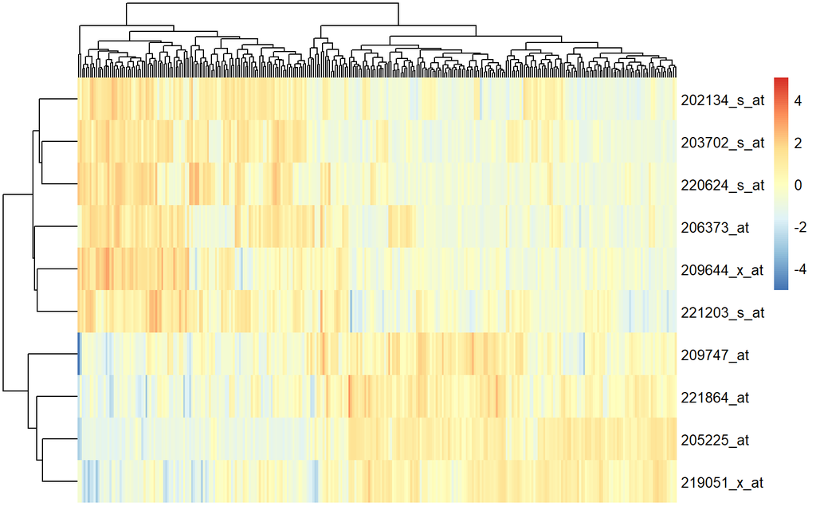

Figure 14: Heatmap of top differentially expressed genes for responders vs. non-responders model.

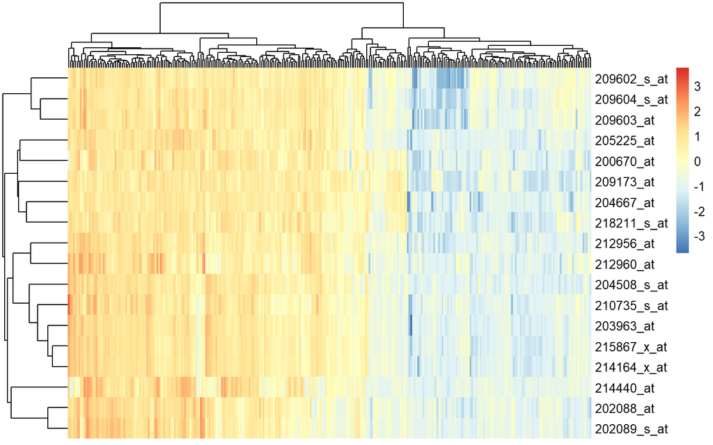

Figure 15: Heatmap of top differentially expressed genes for ER-positive vs. ER-negative model.

## 5.2 Plot the expression levels of one gene

The expression levels of the gene ESR1 (205225_at) were then examined across samples, first grouped by treatment response and then by ER status. The gene shows a clear and strong upregulation in ER-positive tumours compared to ER-negative tumours. In contrast, when grouped by response status, ESR1 expression is lower in responders than in non-responders, although the difference is weaker and less consistent. Overall, the variation observed in the responder group appears to be largely driven by differences in ER status

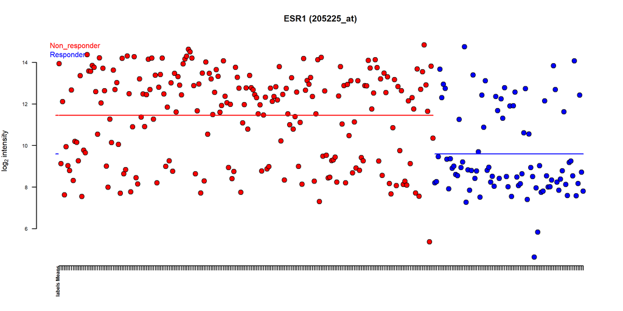

Figure 16: Expression of ESR1 (205225_at) across samples grouped by responders and non-responders.

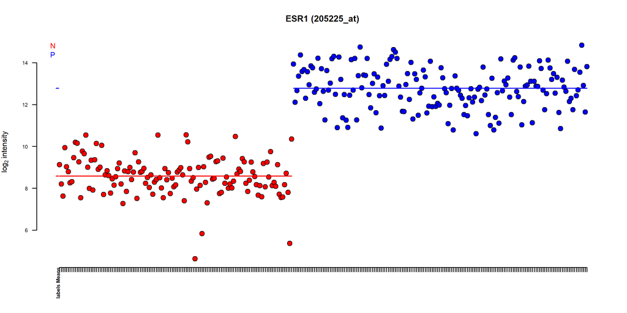

Figure 17: Expression of ESR1 (205225_at) across samples grouped by ER-positive vs. ER-negative.

# 6 Classification

To evaluate the predictive performance of gene expression signatures, I used nested loop cross-validation (NLCV). Random forest–based approach was used for feature selection. Classification performance was assessed using multiple algorithms, including diagonal linear discriminant analysis (DLDA), random forest, bagging, PAM, and support vector machines (SVM).

Model performance was evaluated using misclassification rates and visualized across methods to compare classification accuracy and stability.

## 6.1 Classification of treatment response

Figure 19 shows the proportion of correct classifications for each sample across all NLCV runs. This reveals a subset of samples that are consistently misclassified in every iteration, suggesting that these cases are more difficult to classify.

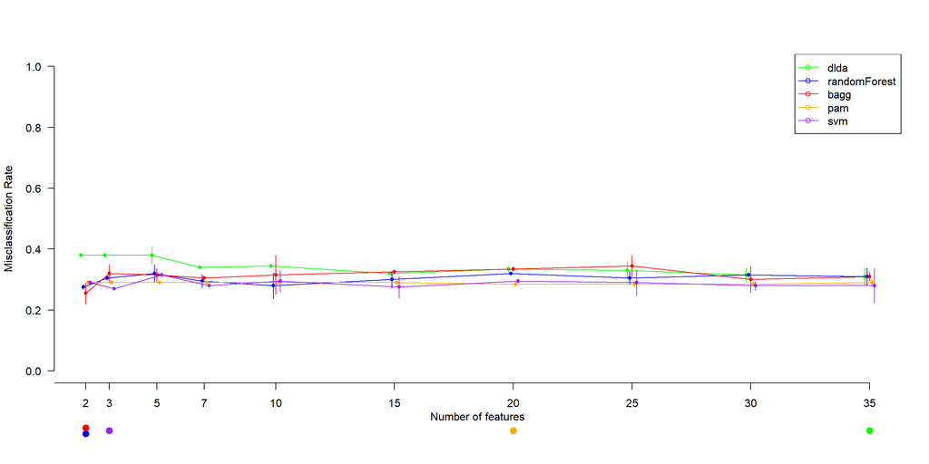

Figure 18: Performance of different classification methods to identify responders vs. non-responders

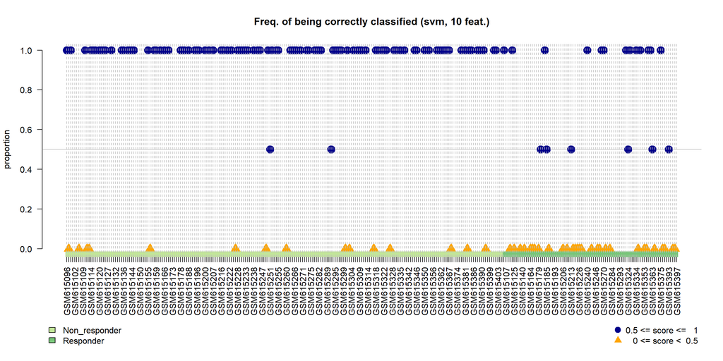

Figure 19: The proportion of each sample of being correctly classified across all runs of nclv

## 6.2 Classification of ER Status

For ER status classification, the mean squared error (MSE) is low across all classifiers even after selecting only 10 genes, suggesting that a relatively small gene signature is sufficient to accurately distinguish ER-positive from ER-negative samples (Figure 20). This indicates a strong and robust biological signal between the ER groups, consistent with our previous findings from the exploratory and differential expression analyses.

When examining the proportion of correct classifications for each sample across all NLCV runs, the classifier shows consistently high accuracy. Most samples are correctly predicted in nearly all runs, demonstrating stable performance. Only a single outlier shows instability, with frequent misclassification across runs, suggesting it may have an ambiguous or less typical expression profile (Figure 21).

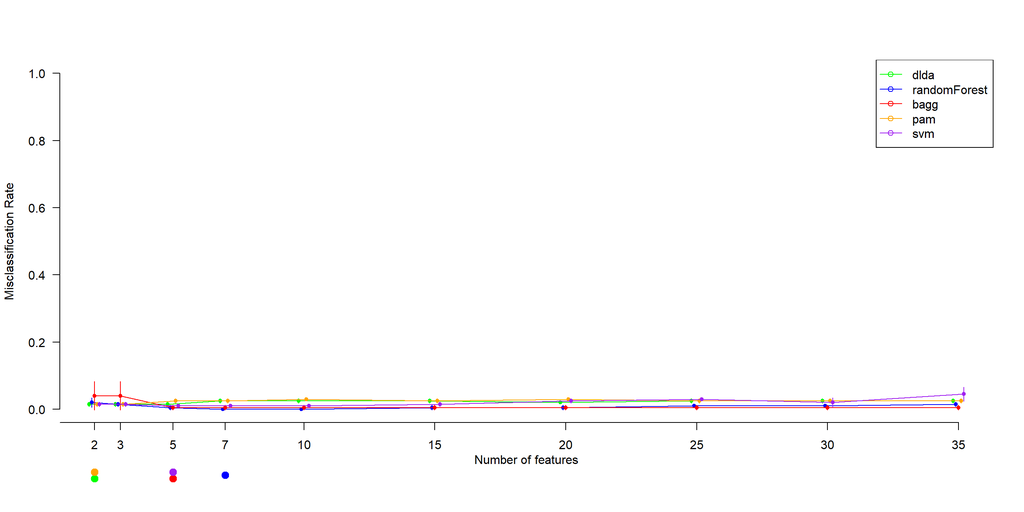

Figure 20: Performance of different classification methods to identify ER-positive and ER-negative samples

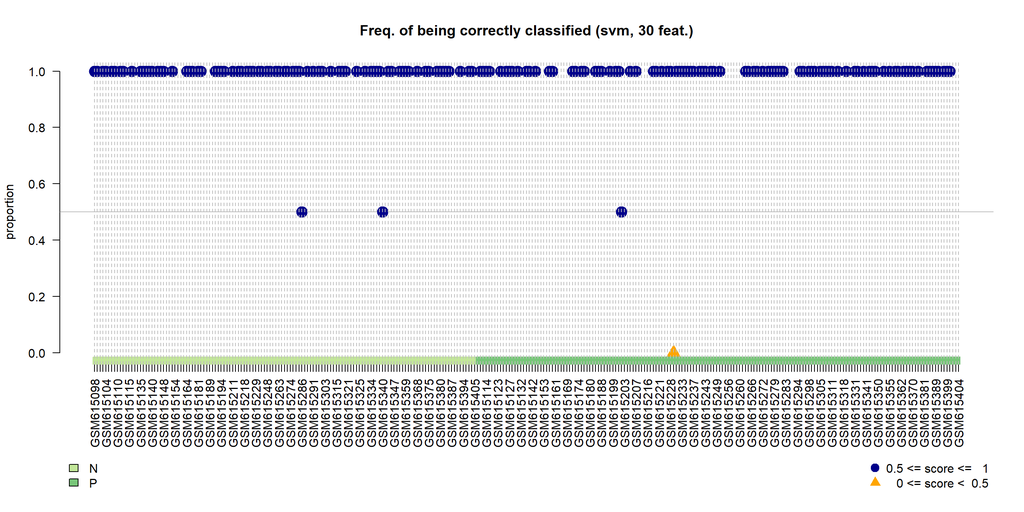

Figure 21: The proportion of each sample of being correctly classified across all runs of nclvs

# 7 Pathway Analysis Using MLP

Pathway analysis is a method used to find which biological processes are most affected in a list of genes, helping to understand what is happening in the cell. Since the treatment response classifier showed limited performance, pathway analysis was conducted only for the ER status comparison.

Overall, the results group into three main biological themes: urogenital system development, miRNA metabolic processes, and mammary gland morphogenesis.

Although prostate-related pathways were the most statistically significant, miRNA regulation and mammary gland epithelial development involved more genes, suggesting they may affect broader biological processes.

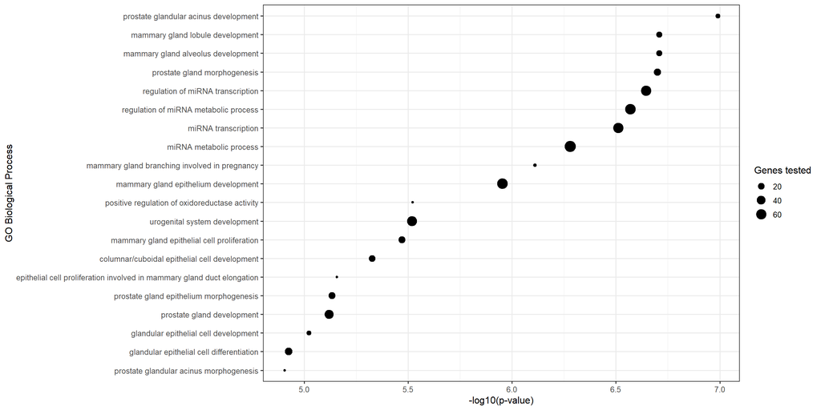

Figure 22: MLP Pathway Enrichment

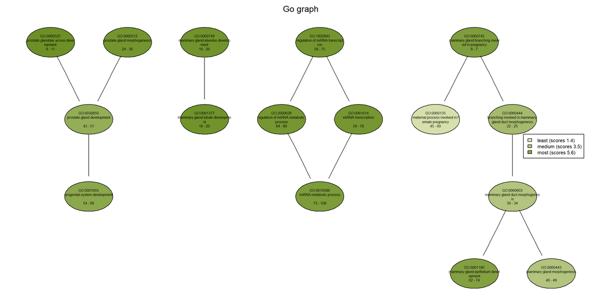

# 8 Conclusion

In conclusion, this analysis identified clear differences in gene expression across breast cancer clinical groups, with ER status showing the strongest and most consistent biological signal. While treatment response was associated with differential gene expression, part of this effect was explained by confounding factors such as ER status and tumour grade. Classification analyses confirmed that ER status can be predicted with high accuracy, whereas treatment response remains more difficult to classify. Finally, pathway analysis highlighted key biological processes related to glandular development and regulatory mechanisms, providing further insight into the biological mechanisms underlying breast cancer.

# 9 Software used

[output not shown]